# Ecological distance

**TipHere you will learn**

Different ecological distance and proximity metrics implemented in ConScape.

# Demonstration of distance and proximity metrics

In this notebook we demonstrate different types of distances and proximities that can be used in ConScape to quantify the connectivity between source and target pixels.

## Data import

See notebook Getting Started for a ‘basic workflow’ to learn about the fundamentals on data import and the creation of a ConScape `Grid`:

```
"/home/runner/work/ConScape.jl/ConScape.jl/src/../data"
```

```
┌ 117×87 RasterStack ┐
├────────────────────┴─────────────────────────────────────────────────── dims ┐
  ↓ X Projected{Float64} 110650.0:1000.0:226650.0 ForwardOrdered Regular Intervals{Start},
  → Y Projected{Float64} 6.98175e6:-1000.0:6.89575e6 ReverseOrdered Regular Intervals{Start}
├────────────────────────────────────────────────────────────────────── layers ┤
  :steplikelihood eltype: Float64 dims: X, Y size: 117×87
  :quality        eltype: Float64 dims: X, Y size: 117×87
├────────────────────────────────────────────────────────────────────── raster ┤
  missingval: NaN
  extent: Extent(X = (110650.0, 227650.0), Y = (6.89575e6, 6.98275e6))
  crs:
└──────────────────────────────────────────────────────────────────────────────┘
```

```
RandomisedShortestPath{ExpectedCost, MinusLog, Float64, Float64}(ExpectedCost(), MinusLog(), 0.001, 1.0, false)
```

## Euclidean distance

Compute the Euclidean distance for our target pixel 4300. Here we pass extra argumenst to `solve`, `1` for the first subgraph, and I for the spatial index of the target pixel.

```
┌ 117×87 Raster{Float64, 2} ┐
├───────────────────────────┴──────────────────────────────────────────── dims ┐
  ↓ X Projected{Float64} 110650.0:1000.0:226650.0 ForwardOrdered Regular Intervals{Start},
  → Y Projected{Float64} 6.98175e6:-1000.0:6.89575e6 ReverseOrdered Regular Intervals{Start}
├────────────────────────────────────────────────────────────────────── raster ┤
  extent: Extent(X = (110650.0, 227650.0), Y = (6.89575e6, 6.98275e6))
  crs:
└──────────────────────────────────────────────────────────────────────────────┘
      ↓ →    6.98175e6    6.98075e6    6.97975e6  …    6.89675e6    6.89575e6
 110650.0  NaN          NaN          NaN             NaN          NaN
 111650.0  NaN          NaN          NaN             NaN          NaN
 112650.0  NaN          NaN          NaN             NaN          NaN
 113650.0  NaN          NaN          NaN             NaN          NaN
      ⋮                                           ⋱
 223650.0  NaN          NaN          NaN             NaN          NaN
 224650.0  NaN          NaN          NaN          …  NaN          NaN
 225650.0  NaN          NaN          NaN             NaN          NaN
 226650.0  NaN          NaN          NaN             NaN          NaN
```

```
GLMakie.Screen(...)
```

## Least-cost distance

From the `Grid` we can also compute the least-cost distances betweem $s$ and $t$:

```
┌ 117×87 Raster{Float64, 2} ┐
├───────────────────────────┴──────────────────────────────────────────── dims ┐
  ↓ X Projected{Float64} 110650.0:1000.0:226650.0 ForwardOrdered Regular Intervals{Start},
  → Y Projected{Float64} 6.98175e6:-1000.0:6.89575e6 ReverseOrdered Regular Intervals{Start}
├────────────────────────────────────────────────────────────────────── raster ┤
  extent: Extent(X = (110650.0, 227650.0), Y = (6.89575e6, 6.98275e6))
  crs:
└──────────────────────────────────────────────────────────────────────────────┘
      ↓ →    6.98175e6    6.98075e6    6.97975e6  …    6.89675e6    6.89575e6
 110650.0  NaN          NaN          NaN             NaN          NaN
 111650.0  NaN          NaN          NaN             NaN          NaN
 112650.0  NaN          NaN          NaN             NaN          NaN
 113650.0  NaN          NaN          NaN             NaN          NaN
      ⋮                                           ⋱
 223650.0  NaN          NaN          NaN             NaN          NaN
 224650.0  NaN          NaN          NaN          …  NaN          NaN
 225650.0  NaN          NaN          NaN             NaN          NaN
 226650.0  NaN          NaN          NaN             NaN          NaN
```

The least-cost distance from all source pixels to target pixel 4300 is:

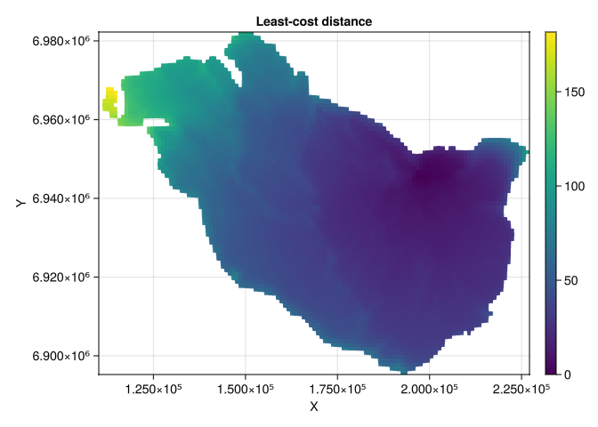

Least-cost distance to target t.

Not too surprising there is a high, albeit imperfect, correlation between the Euclidean and least-cost distance:

```
0.9111063562084138
```

## RSP expected cost distance

The randomized shortest path (RSP) expected cost distance is the expected cost of moving from the source to the target following the RSP distribution:

```
┌ 117×87 Raster{Float64, 2} ┐
├───────────────────────────┴──────────────────────────────────────────── dims ┐
  ↓ X Projected{Float64} 110650.0:1000.0:226650.0 ForwardOrdered Regular Intervals{Start},
  → Y Projected{Float64} 6.98175e6:-1000.0:6.89575e6 ReverseOrdered Regular Intervals{Start}
├────────────────────────────────────────────────────────────────────── raster ┤
  extent: Extent(X = (110650.0, 227650.0), Y = (6.89575e6, 6.98275e6))
  crs:
└──────────────────────────────────────────────────────────────────────────────┘
      ↓ →    6.98175e6    6.98075e6    6.97975e6  …    6.89675e6    6.89575e6
 110650.0  NaN          NaN          NaN             NaN          NaN
 111650.0  NaN          NaN          NaN             NaN          NaN
 112650.0  NaN          NaN          NaN             NaN          NaN
 113650.0  NaN          NaN          NaN             NaN          NaN
      ⋮                                           ⋱
 223650.0  NaN          NaN          NaN             NaN          NaN
 224650.0  NaN          NaN          NaN          …  NaN          NaN
 225650.0  NaN          NaN          NaN             NaN          NaN
 226650.0  NaN          NaN          NaN             NaN          NaN
```

The RSP expected cost from all pixels as sources to target pixel 4300:

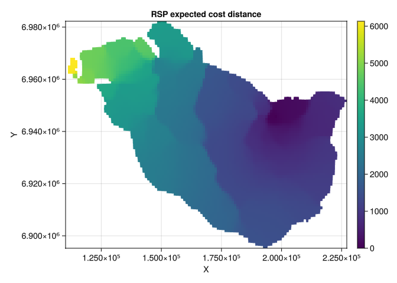

RSP expected cost distance to target t.

Comparing the least-cost distance to the RSP expected cost distance we see there is strong positive relationship:

```
0.937208136277493
```

Most computations in ConScape require a proximity instead of a distance. A proximity is a metric from zero to one, with zero no connectivity and one perfect connectivity between a source and a target. Different transformations can be used for this, a common choice is the exponential transformation with a scaling factor (here: 1000) representing the movement capabilities of a species (see (Moorter et al. 2021) for a discussion):

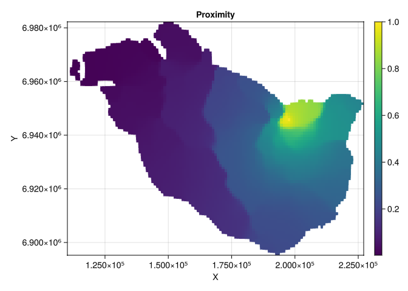

## Survival probability

(Fletcher Jr et al. 2019) introduced the use of the ‘absorbing Markov chain’ or ‘killed random walk’ to connectivity modeling in landscape ecology (see also: (Moorter et al. 2021)). The RSP framework uses the same formalism and can be considered a generalization of the absorbing Markov chain in ((Fletcher Jr et al. 2019)) with the introduction of the $\theta$ paramter, see ((Moorter et al. 2021)) for discussion. Here we show ConScape’s functionality to use the survival probability from source to target as a proximtiy metric:

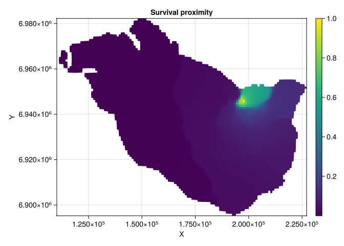

Survival proximity to target t.

The proximity based on the expected cost and on the survival probability show a strong positive relationship:

```
0.8203037427442533
```

For more discussion on the use of the survival probability, in the context of the RSP framework we refer to ((Moorter et al. 2021)) and more specifically in the context of ConScape to Notebook dispersal mortality.

## Summary

In ConScape different metrics are available to characterize the connectivity between source and target pixels. The metric that is most appropriate will depend upon the ecological application. (Moorter et al. 2021) suggest the use of the RSP expected cost for applications modeling individuals that move with knowledge of their landscape, whereas the survival probability is probably a more appropriate model for dispersing individuals experiencing mortality ((Fletcher Jr et al. 2019) for this last type of applications).

Fletcher Jr, Robert J, Jorge A Sefair, Chao Wang, Caroline L Poli, Thomas AH Smith, Emilio M Bruna, Robert D Holt, Michael Barfield, Andrew J Marx, and Miguel A Acevedo. 2019. “Towards a Unified Framework for Connectivity That Disentangles Movement and Mortality in Space and Time.” *Ecology Letters* 22 (10): 1680–89.

Moorter, Bram van, Ilkka Kivimäki, Manuela Panzacchi, and Marco Saerens. 2021. “Defining and Quantifying Effective Connectivity of Landscapes for Species’ Movements.” *Ecography* 44 (6): 870–84.